# Blog Post: LeBron James’s Effort to Win

Talya Zalipsky

5/5/2020

How much effort do players put into each basketball game? How does that effort change over time? And how can we predict how much effort they will put in in the future?

Today, we’re looking at “effort to win,” a metric that measures the individual physical exertion and contribution that players make to win the game. To get a sense of the long and short term trends in this metric, we’ll take a look at LeBron James’s nice, long NBA career, with 82 games a season for 17 seasons. We have his effort to win (E2W) for every game played between 2003 and the end of the 2018-2019 season, 1198 games in total.

In order to predict his future E2W, we need to get a sense of the short term and long term trends in James’s playing.

We’ll start with the long term: in the graph below, it’s clear that there’s a long term decline in James’s E2W. Maybe due to age, maybe due to overconfidence - who’s to say? The point is, although there’s a lot of up and down variation, in the long run, his effort is decreasing. We fit a simple line to account for that trend, and we can move on to looking at the short term variations.

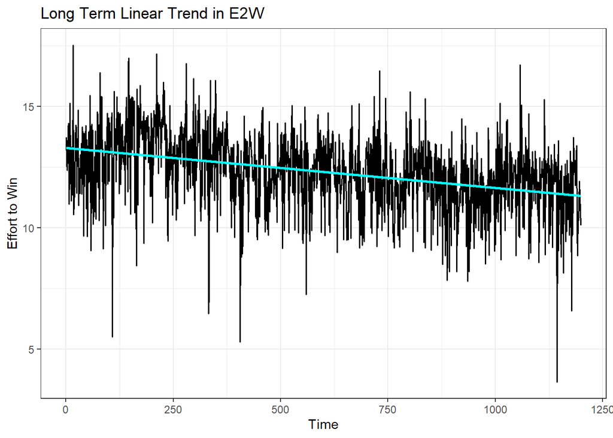

In the short term, it’s clear from the plot above that there’s a lot of variation. Maybe James is tired one day, maybe he’s distracted, maybe he’s had a power protein shake and is feeling super motivated. There are definitely a lot of moving parts that factor into how much energy a player has and how much effort he’s going to put in.

In statistics, we have a few strategies for modeling this sort of thing, but the central concept is going to be using a few past values to predict the next one. For example, using some combination of the E2W values for the last three games to calculate the E2W for the next one.

In fact, this turns out to be a pretty good fit! Intuitively, the amount of effort you’re ready to put into your next game is pretty closely related to how well you’ve played in the last few games: how much energy you’ve had, how your personal life has been, how much confidence you feel, etc.

So, we can add into our model a weighted combination of the last three E2W values. Now, we have a linear trend, plus the last three games, capturing the long term and the short term values.

Our goal is to predict the E2W of James’s next 10 games, so the most important feature in our model is its predictive power. In order to select this model, we used a process called cross-validation, which fits the model for only part of the dataset, tries to predict the next 10 values based on that, and then compares them to the actual next 10 values, for several different subsections of the data.

Compared to the other models we looked at, this combination of linear fit and the last three values produced the closest predictions to the actual values, so this is the one we chose!

Finally, let’s look at the E2W values that our model predicted for the next 10 games. These are the first 10 games of the 2019-2020 season. Below, we plotted James’s E2W since 2014, with the 10 predictions in red.

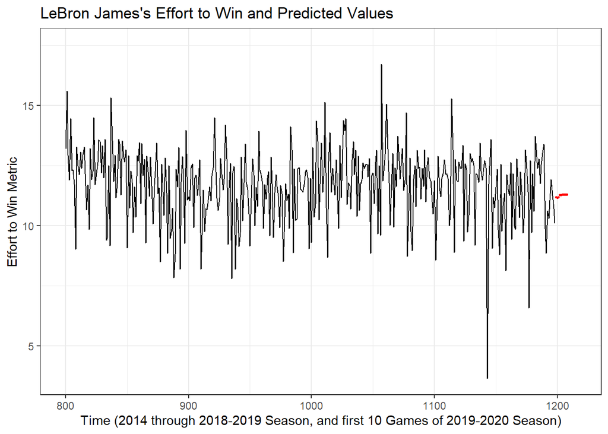

We can see that the predictions look a lot smoother than the actual data. That’s because there’s a lot of random variation that goes into this metric! However, the predictions also look reasonable considering the typical behavior of the rest of this graph.

So far, it seems like James’s declining E2W has served him pretty well, but with models like these, we can predict how long he has before he’ll need to step up his game in order to stay on the team!

However, the best way to know James’s E2W is to keep up with basketball news! Let’s see how these predictions hold up this next season, and go Lakers!